# PRV - 4 cell lines: Merge TransFrags into Transcripts using TSSs and TESs

Balázs Kakuk

# Project info

Samples: dcDNA Seq  
pychopper: no  
mapping version: v6  
LoRTIA: yes (stranded only output)

# TO-DO:

## Integrate NRK cell line’s other hpi samples

- metadata ✔
- LoRTIA ✔
- bamfiles ✔
- GFF-compare –>> select not the best hit from the all results but the canonic ! ✔
- TransFrags ✔
- TSSr ✔
- prime plots –>> everything, basically…

## Visualization

- Logarithmic scales for gene-pair ratios
- else ?

## Ref Transcripts

- Correct REF annotation’s TES -> there were some very close ->> Gábor & Ádám ✔
- Add canonic (T,F), gene, and CDS to REF transcripts ->> Gábor & Ádám ✔

## Transcript Generation

- Venn diagrams -> how many reads have correct TES or TSS? -> this makes sense only sample-wise… –> check if there are TransFrags that have no correct TSS or TES, or rather –> make a distribution of in how many sample groups correct prime3 and prime5 ends were found for each

```
## integer(0)
```

# TSSr Clustering results of CAGE and dcDNA data

## Cluster Widths

### dcDNA TSS

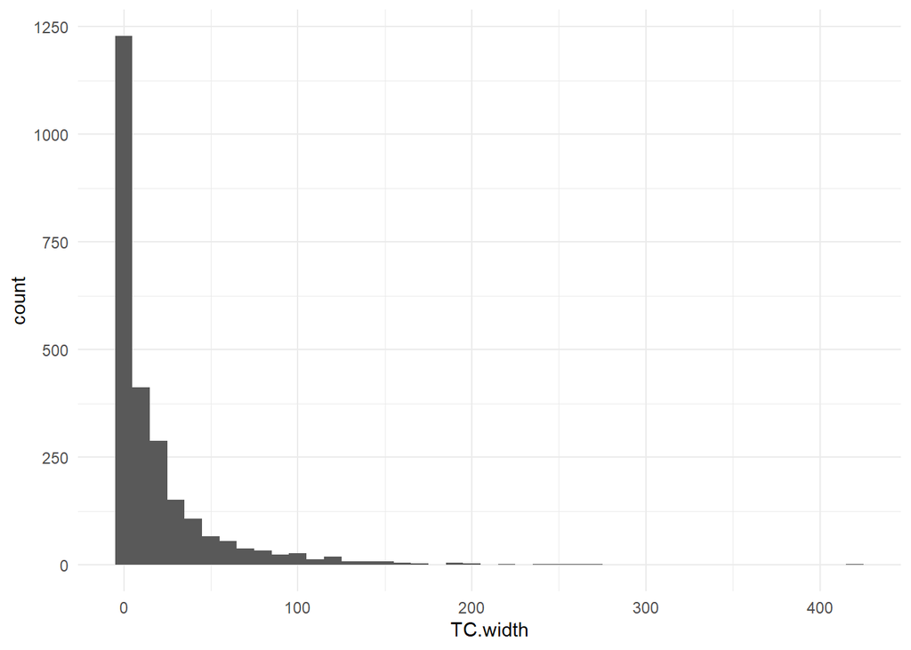

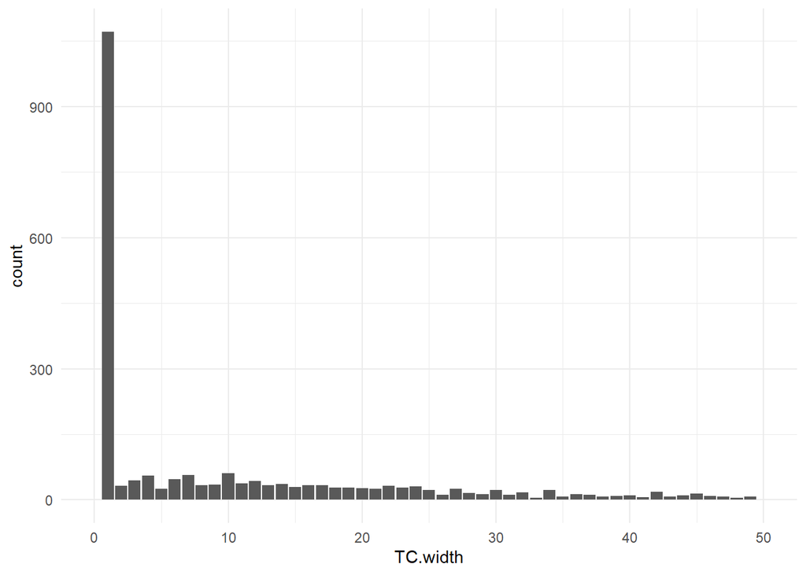

### dcDNA TES

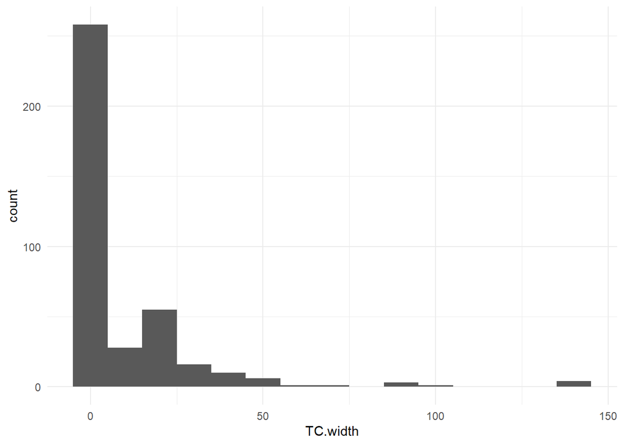

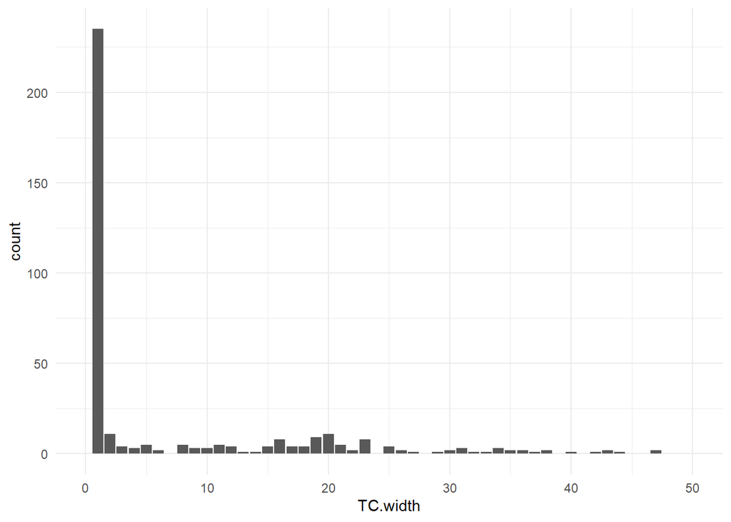

### CAGE

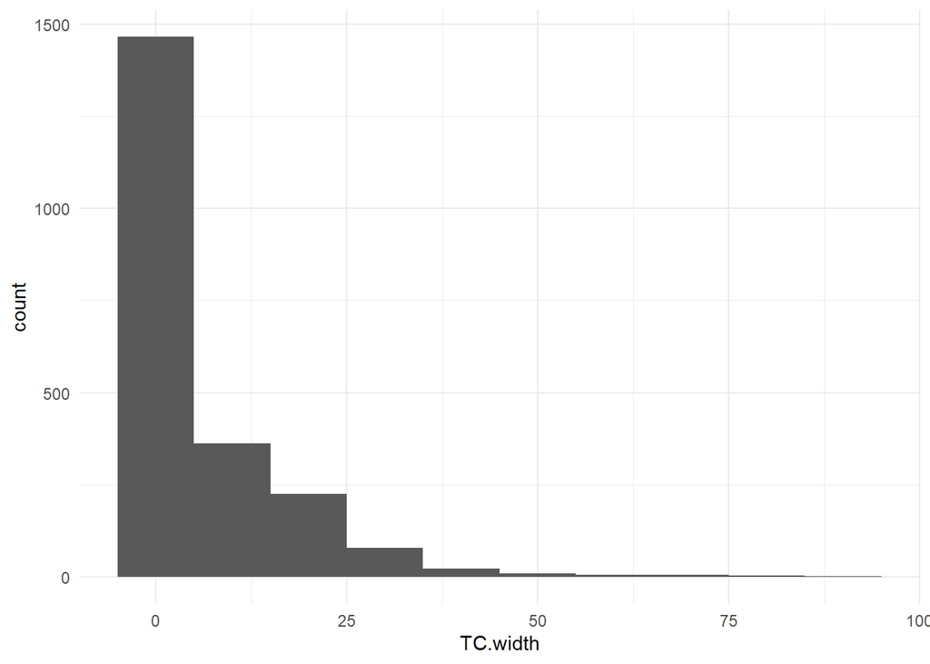

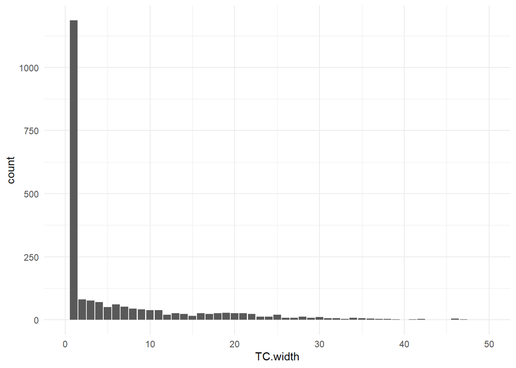

## Assigning clutsers to genes

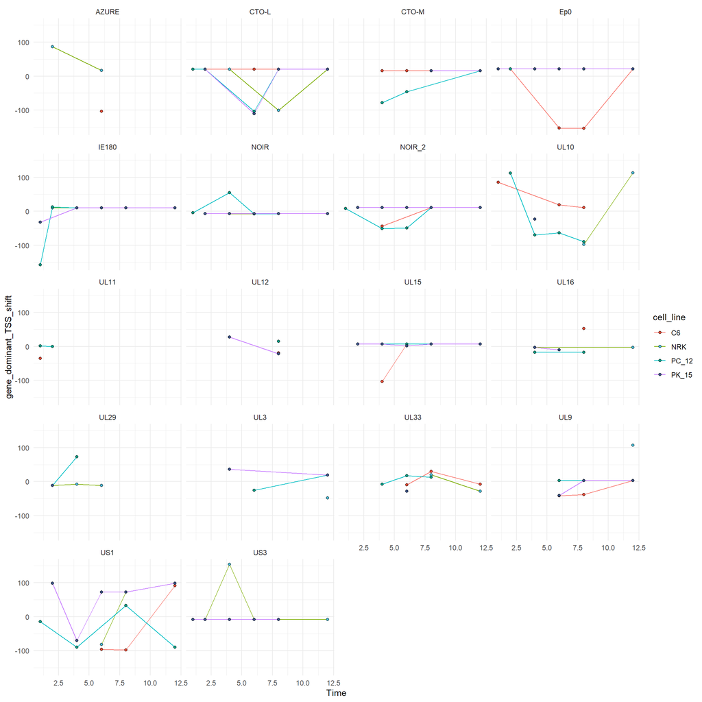

### Plot top20 Gene-Wise Shifts TES

```
## `geom_line()`: Each group consists of only one observation.
## ℹ Do you need to adjust the group aesthetic?
```

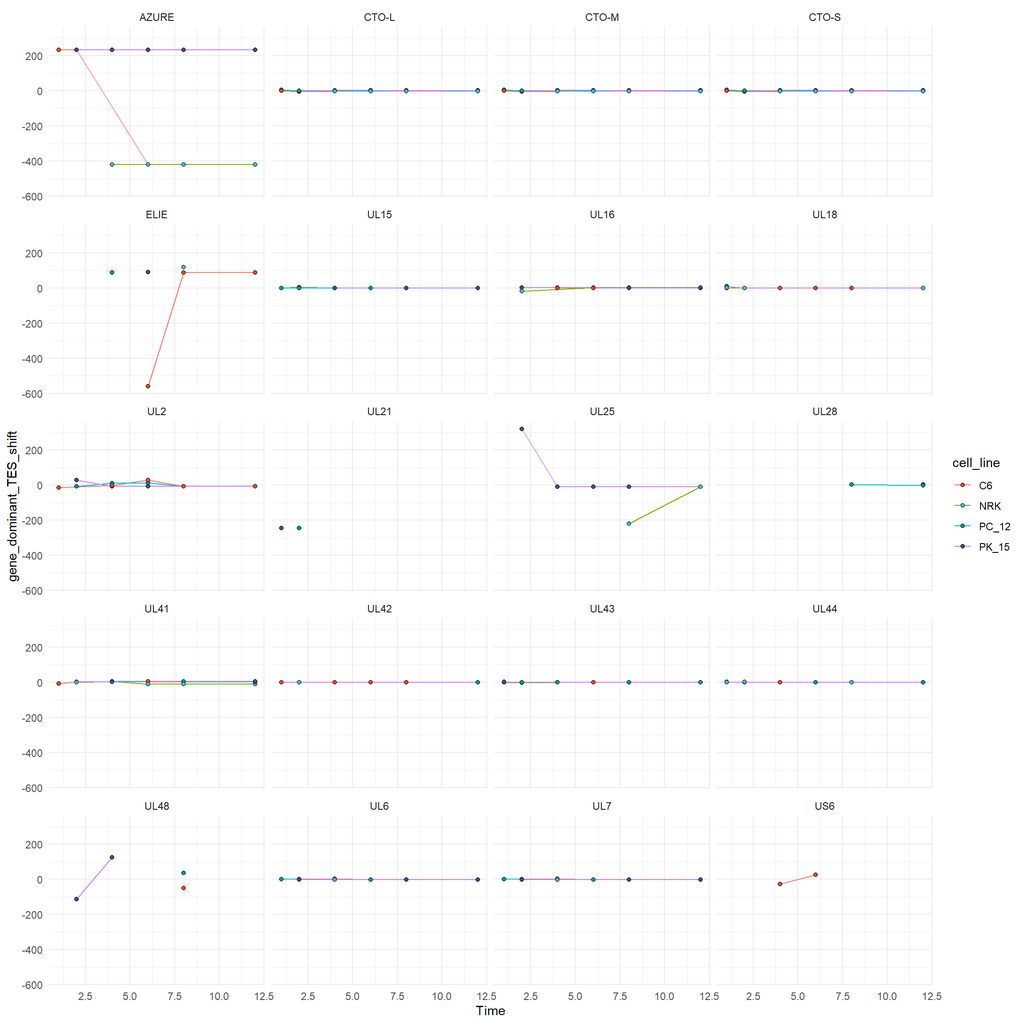

# Merge dcDNA TSSr Clustering results and CAGE TSSr clustering results with TransFrags and Reference Transcripts

## The Transcripts were merged based on their TSS with both the dcDNA-based TSS lusters and the CAGE TSS clusters

## Reference Transcripts

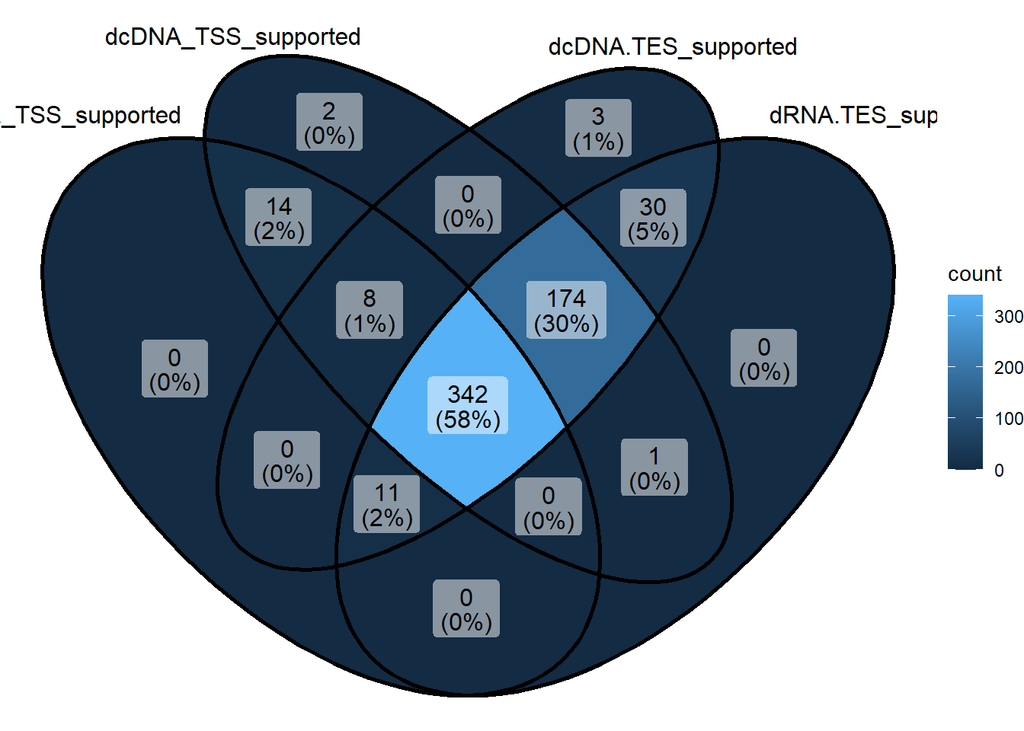

## TransFrags

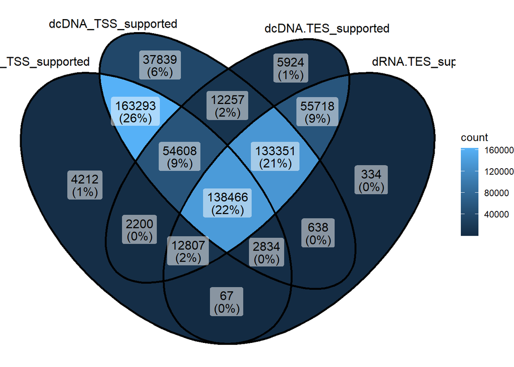

```
##  [1] "dcDNA.TES_TC_ID"           "dcDNA.TES_TC.start"
##  [3] "dcDNA.TES_TC.end"          "dcDNA.TES_support"
##  [5] "dcDNA.TES_score"           "dcDNA.TES_consensus_peak"
##  [7] "dcDNA.TES_TC_significance" "dRNA.TES_TC_ID"
##  [9] "dRNA.TES_TC.start"         "dRNA.TES_TC.end"
## [11] "dRNA.TES_support"          "dRNA.TES_score"
## [13] "dRNA.TES_consensus_peak"   "dRNA.TES_TC_significance"
```

```
##  [1] "CAGE_TC_ID"                "CAGE.TSS_TC.start"
##  [3] "CAGE.TSS_TC.end"           "CAGE.TSS_support"
##  [5] "CAGE.TSS_score"            "CAGE.TSS_consensus_peak"
##  [7] "CAGE_TC_significance"      "dcDNA.TSS_TC_ID"
##  [9] "dcDNA.TSS_TC.start"        "dcDNA.TSS_TC.end"
## [11] "dcDNA.TSS_support"         "dcDNA.TSS_score"
## [13] "dcDNA.TSS_consensus_peak"  "dcDNA.TSS_TC_significance"
```

## Validate TESs of TransFrags

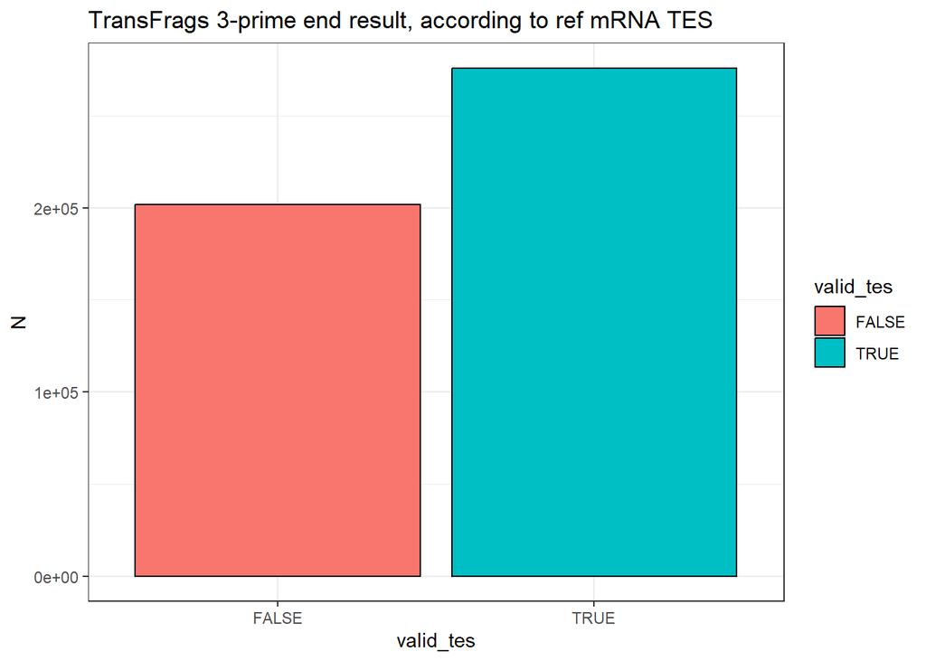

## Annotate new Transcripts from TSS-validated TransFrags

### TransFrags that are not equal to Reference TX

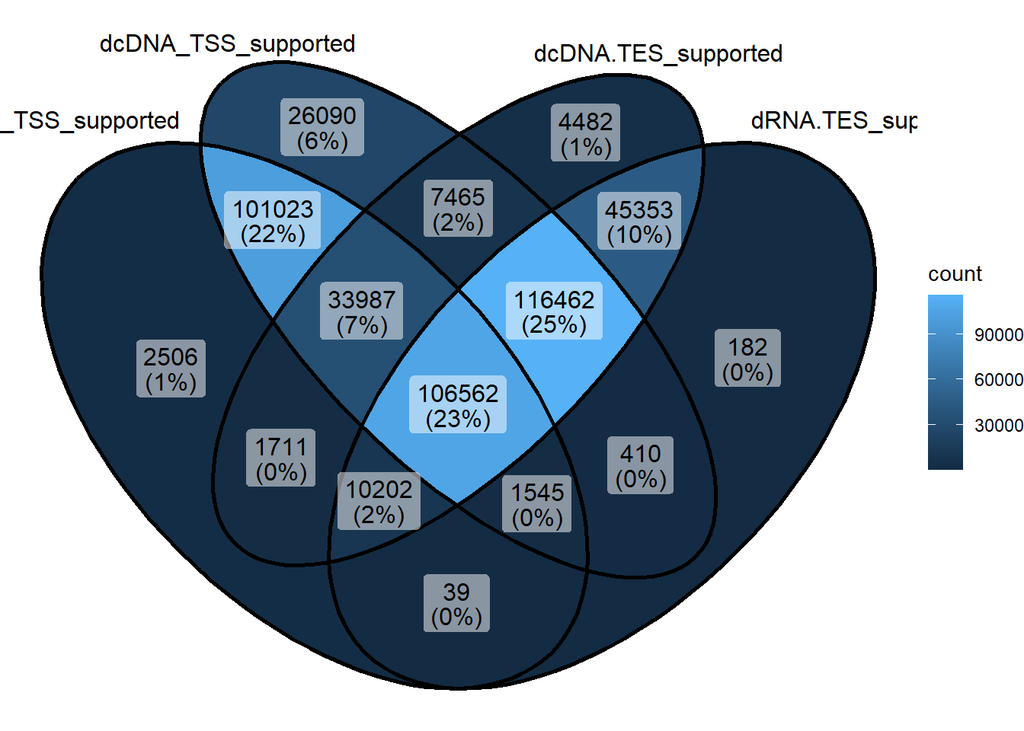

### TransFrags that are have at least ’**’

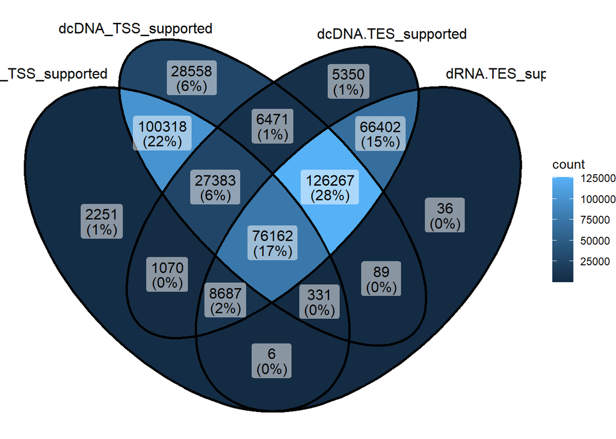

### TransFrags that share 3-prime with previous annotation –>> significant drop

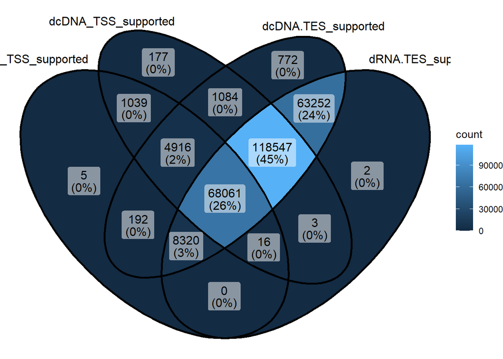

### Filtering of TransFrags

*No filtering the TransFrags now, rather we will filter the final Transcripts*

## Merge TransFrags with TSSr group-wise cluster results (for the peaks)

### Distribution of Transfrags in the sample groups

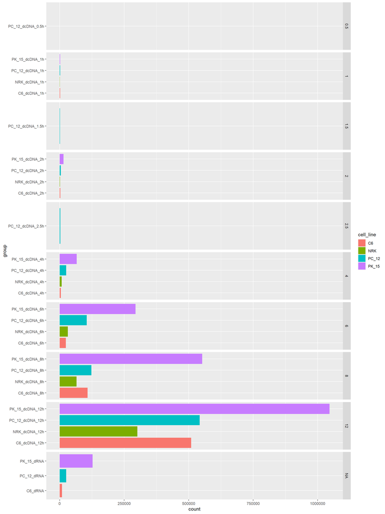

### Distance to dcDNA TSS cluster’s group dominant TSS (peak)

```
##      TSS_dcDNA_distance      N
##                   <int>  <int>
##   1:                 NA 413956
##   2:                -23   4561
##   3:                 12   8193
##   4:                  8   9896
##   5:                 13   7685
##  ---
## 746:               -379      1
## 747:               -377      1
## 748:               -368      1
## 749:               -371      1
## 750:               -364      2
```

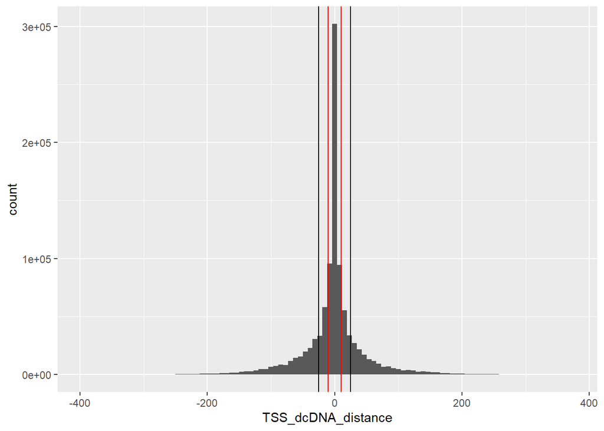

### Distance to dcDNA TSS cluster’s consensus TSS peak

```
##      dcDNA.TSS_consensus_peak_dist     N
##                              <int> <int>
##   1:                            69  1267
##   2:                           -16 10535
##   3:                           -34  4778
##   4:                            41  3074
##   5:                          -102   715
##  ---
## 465:                           177    57
## 466:                           192    12
## 467:                           187    52
## 468:                           191    28
## 469:                           190    36
```

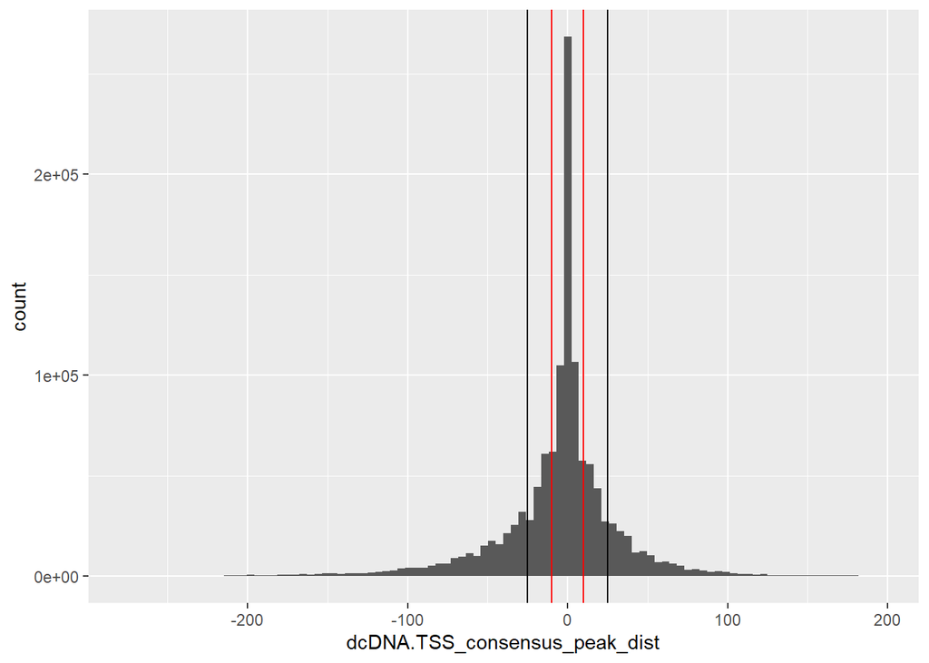

### Distance to CAGE cluster’s dominant TSS (peak)

```
##      TSS_CAGE_distance       N
##                  <int>   <int>
##   1:                NA 1135179
##   2:                 3   11488
##   3:                13    2223
##   4:                -9    4613
##   5:                15    1701
##  ---
## 209:               133       2
## 210:               121       1
## 211:               122       1
## 212:               124       1
## 213:               120       1
```

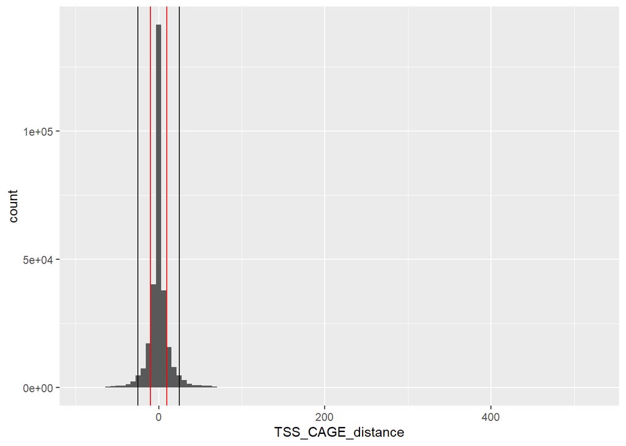

### Distance to CAGE TSS cluster’s consensus TSS peak

```
##      CAGE.TSS_consensus_peak_dist      N
##                             <int>  <int>
##   1:                           NA 616050
##   2:                            2  35685
##   3:                          -10  17408
##   4:                           10  16372
##   5:                          -12  11642
##  ---
## 129:                          -60     86
## 130:                          -59    119
## 131:                          -58     77
## 132:                          -56     39
## 133:                          -87     40
```

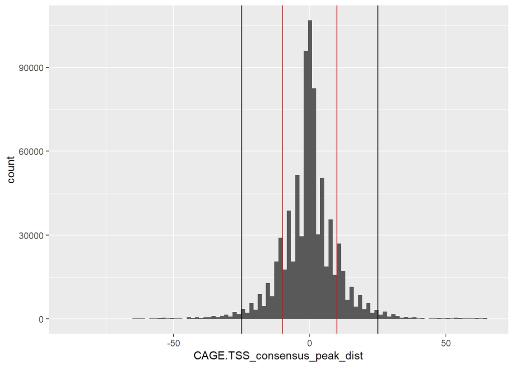

### Distance to dcDNA TES cluster’s group dominant TES (peak)

```
##      TES_dcDNA_distance      N
##                   <int>  <int>
##   1:                 NA 329776
##   2:                  0 513534
##   3:                -11   2486
##   4:                -10   4106
##   5:                -20    775
##  ---
## 142:                -60      1
## 143:                 68      4
## 144:                -65      2
## 145:                -69      2
## 146:                -71      2
```

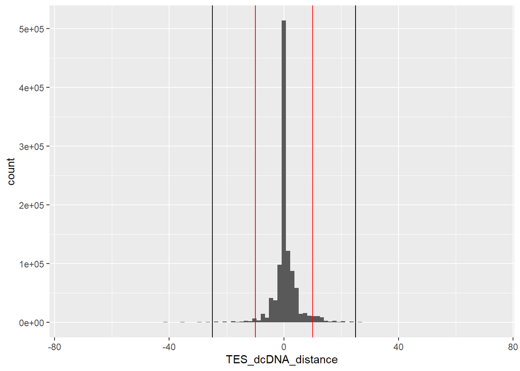

### Distance to dcDNA TES cluster’s consensus TES peak

```
##      dcDNA.TES_consensus_peak_dist      N
##                              <int>  <int>
##   1:                            NA 236576
##   2:                           -24    595
##   3:                           -25    544
##   4:                           -19    709
##   5:                           -11   2659
##  ---
## 137:                           -70      2
## 138:                           -65      2
## 139:                           -63      1
## 140:                           -71      2
## 141:                           -62      1
```

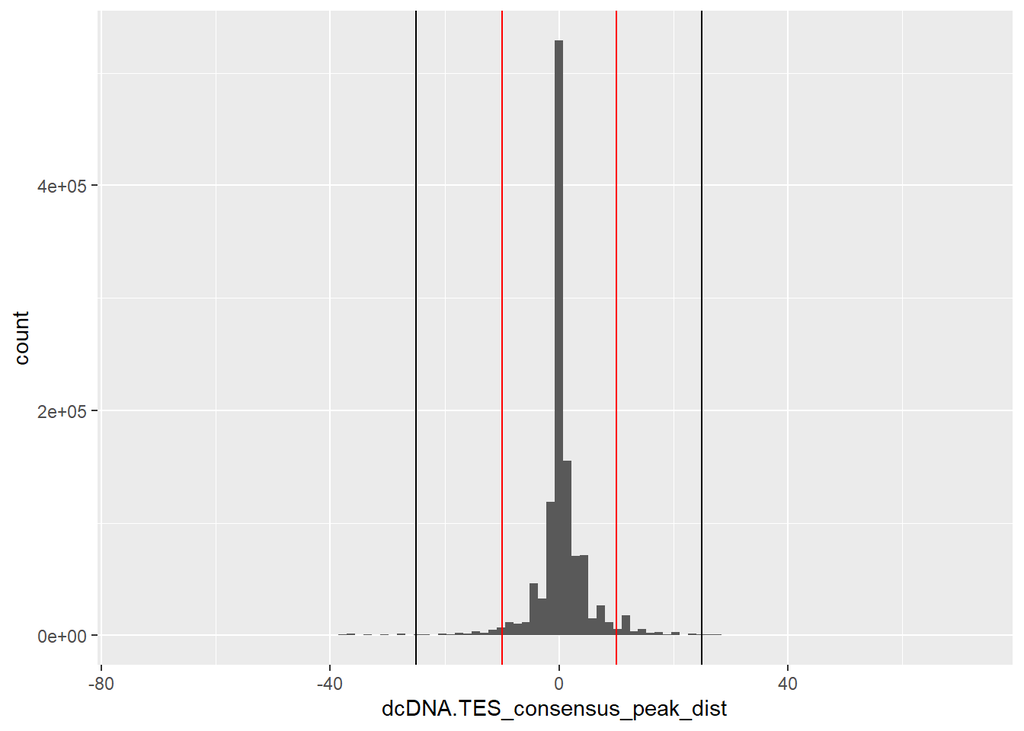

### Distance to dRNA TES cluster’s group dominant TES (peak)

```
##     TES_dRNA_distance       N
##                 <int>   <int>
##  1:                NA 1370668
##  2:                 0   33383
##  3:                -2    3325
##  4:                 3    3070
##  5:                 4     926
##  6:                 6    1258
##  7:                 7     727
##  8:                 2    2778
##  9:                 5    1273
## 10:                11     202
## 11:                -4    1193
## 12:                 8     566
## 13:                -1    1176
```

[output cut: 40 more lines]

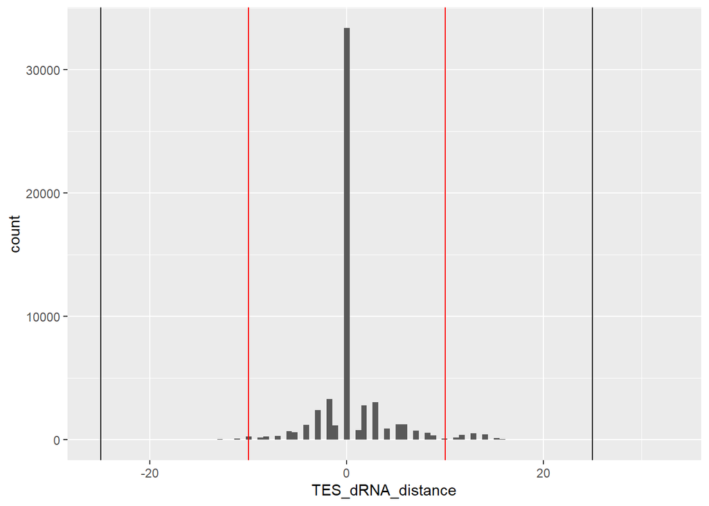

### Distance to dRNA TES cluster’s consensus TES peak

```
##     dRNA.TES_consensus_peak_dist      N
##                            <int>  <int>
##  1:                           NA 310741
##  2:                            0 526842
##  3:                           -2  59475
##  4:                            3  88925
##  5:                            4  26302
##  6:                            6  15683
##  7:                            7   9495
##  8:                            2  86972
##  9:                            1  44342
## 10:                           10   4181
## 11:                           -1  40796
## 12:                            5  35432
## 13:                           14   2947
```

[output cut: 50 more lines]

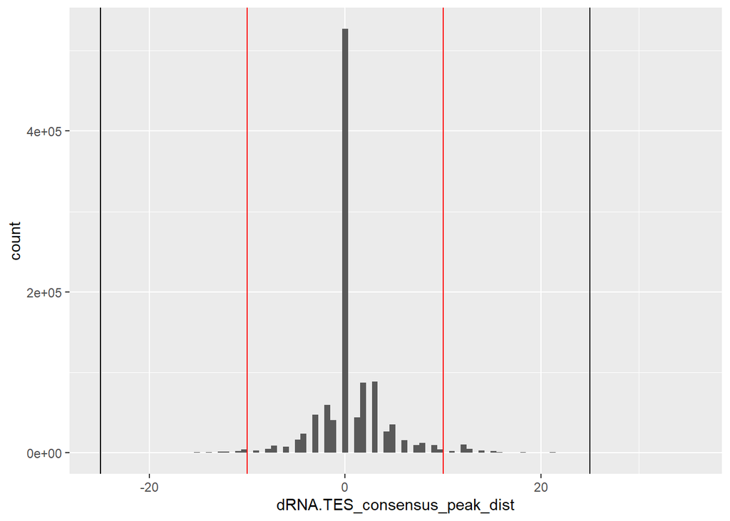

## TransFrags that share 5-primes with CAGE or dcDNA TSS cluster peak in the respective sample group with a +/- 10 bp wobble

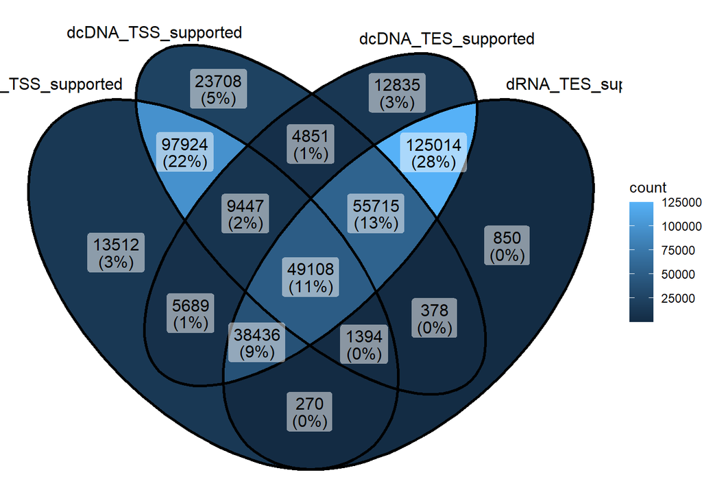

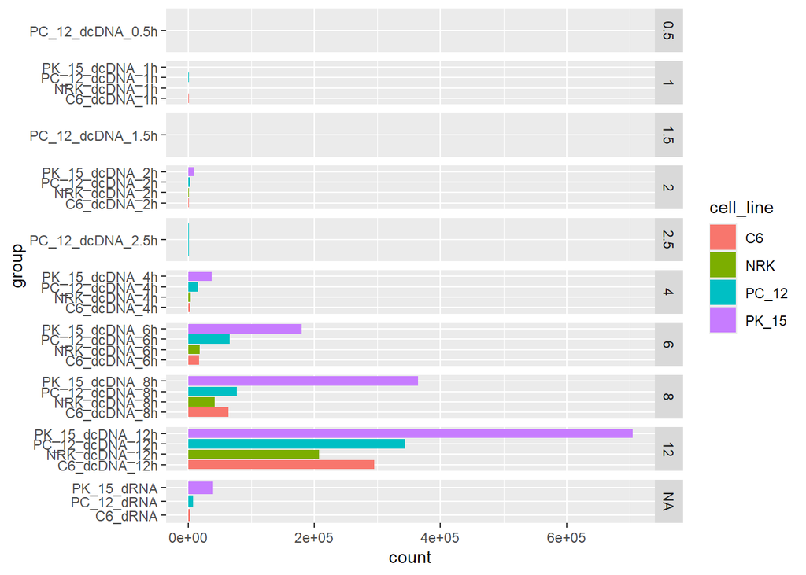

*The TSS here will thus be the Group-Wise DOMINANT peak of the dcDNA-based TC – or, if thats missing, that of the Group-Wise DOMINANT CAGE peak,*  
*considering the +/- 10 bp wobble*

*There are many TransFrags that had no TSS or TES in the given sample group*

```
## [1] 95249
```

```
## [1] 5669
```

*The TSS here will thus be the CONSENSUS peak of the dcDNA-based TC – or, if thats missing, that of the CAGE-based CONSENSUS peak,*  
*considering the +/- 10 bp wobble*

```
## [1] 0
```

```
## [1] 0
```

### Assemble Transcripts based on TSS and TES

```
##    valid_tss      N
##       <lgcl>  <int>
## 1:     FALSE 360971
## 2:      TRUE 222207
```

```
## [1] 3311
```

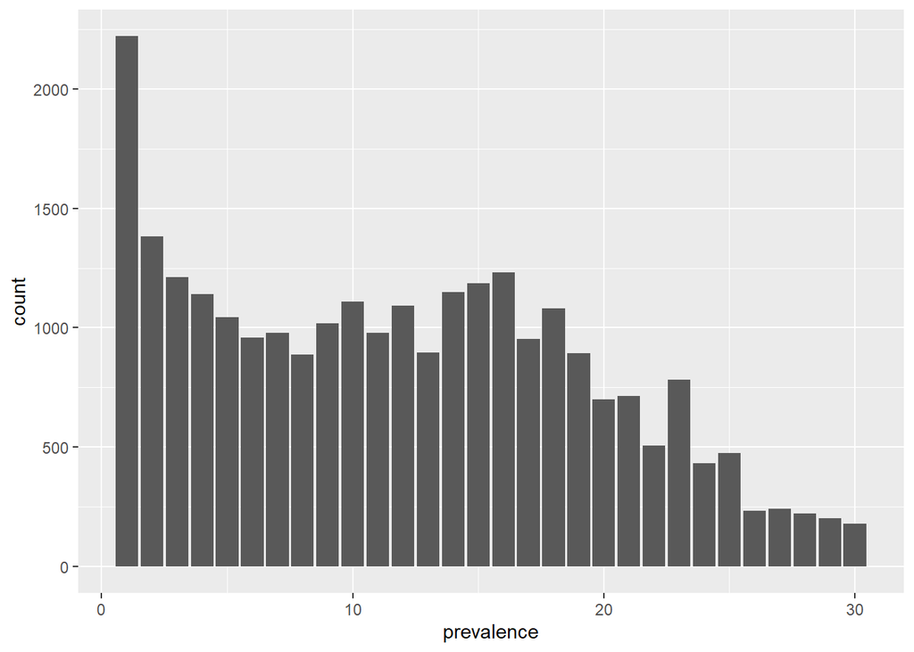

*Filtering for read count : >= 5*  
*Filtering for group prevalence : >= 2*

```
## Keeping 2651 out of 5296 Novel Transcripts (50%)
```

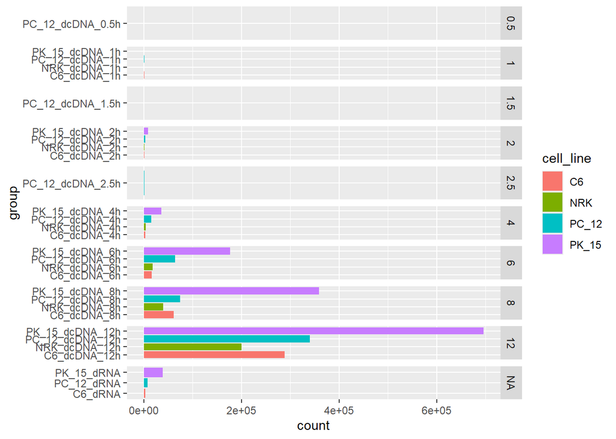

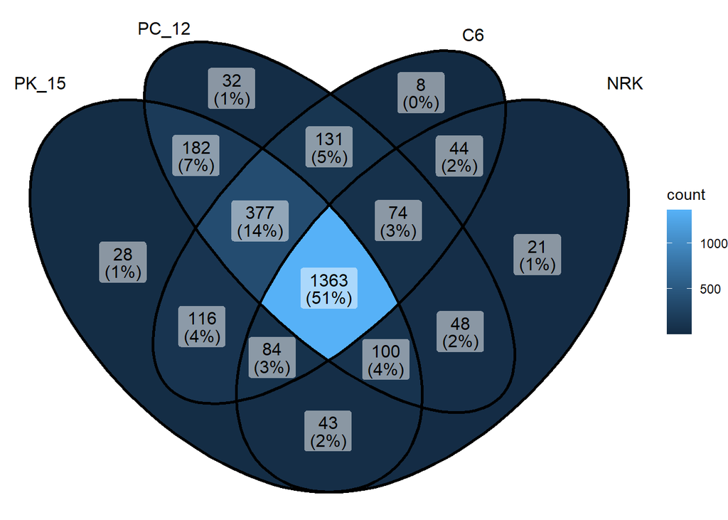

### Include Adapter Counts to Novel Transcripts

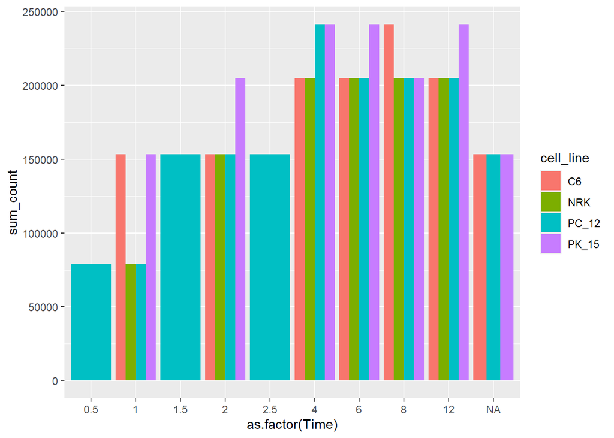

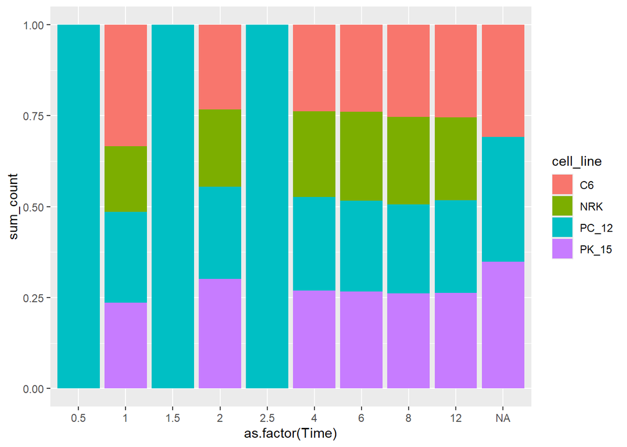

```
## GRanges object with 2651 ranges and 10 metadata columns:
##            seqnames        ranges strand |       TSS       TES   NOV_TX_ID
##               <Rle>     <IRanges>  <Rle> | <numeric> <integer> <character>
##      [1] LT934125.1      779-2273      + |       779      2273    NOV_TX_3
##      [2] LT934125.1      990-2273      + |       990      2273    NOV_TX_5
##      [3] LT934125.1     1036-2273      + |      1036      2273    NOV_TX_6
##      [4] LT934125.1     1102-2273      + |      1102      2273    NOV_TX_7
##      [5] LT934125.1     1170-2273      + |      1170      2273    NOV_TX_9
##      ...        ...           ...    ... .       ...       ...         ...
##   [2647] LT934125.1 135646-136285      - |    136285    135646 NOV_TX_5280
##   [2648] LT934125.1 134888-136368      - |    136368    134888 NOV_TX_5284
##   [2649] LT934125.1 134888-136409      - |    136409    134888 NOV_TX_5285
##   [2650] LT934125.1 134888-136548      - |    136548    134888 NOV_TX_5289
##   [2651] LT934125.1 134888-136683      - |    136683    134888 NOV_TX_5291
##          sum_count        type           source     score     phase          ID
```

[output cut: 27 more lines]

```
## Empty data.table (0 rows and 14 cols): seqnames,strand,TSS,TES,NOV_TX_ID,sum_count...
```

### Include Gene from Reference Transcripts

### Include TES from TSSr’s TES analysis

### Use Gff-compare to compare Novel TXs to ALL REFERENCE Transcripts and select the CLOSEST REFERENCE

```
##     class_code     N
##         <char> <int>
##  1:          =   466
##  2:          m     4
##  3:    3`-long    30
##  4:   5`-short  1035
##  5:    5`-long   766
##  6:   3`-short    58
##  7:          x   106
##  8:          ~    34
##  9:          k     1
## 10:          c   116
## 11:          o    83
## 12:          p     4
```

```
##     class_code     N
##         <char> <int>
##  1:    3`-long     9
##  2:   3`-short    50
##  3:   5`-short  1349
##  4:    5`-long   336
##  5:          ~    21
##  6:          m    18
##  7:          c   361
##  8:          e    25
##  9:          o    16
## 10:          k     3
## 11:          p    48
## 12:          n     1
```